# Data Analyst Nanodegree Project 6: Exploring 5 Years of Cryptocurrency Data

Tyler Watkins

06-Feb-2018

========================================================

## Introduction

In this exploration I look at Cryptocurrency Market Data.

The dataset is the historical cryptocurrency data for all tokens scraped from https://coinmarketcap.com/.

#### Dataset details

Includes all historic open, high, low, close, trading volume and market cap info for all cryptocurrencies. As well as two extra variables, close_ratio and spread.

Close ratio is the daily close rate, min-maxed with the high and low values for the day. Spread is the USD difference between the high and low values for the day.

- Observations: 672,996
- Variables: 14
- Crypto Tokens: 1,494
- Data taken from 28-Apr-2013 to 28-Jan-2018

Dataset was scraped from https://coinmarketcap.com/ on 29-Jan-2018 and saved as file: ‘coinmarket_290118.csv’

Scraping package can be found at https://github.com/JesseVent/crypto

#### Exploration

In this exploration I will attempt gain an understanding of the distribution of the crypto token landscape as it stood on 28-Jan-2018.

I will also look at how the landscape has changed over time since coinmarketcap.com started tracking these tokens in 2013.

My main interest is in the exploring the overall market capitalization, number of tokens, trading volume and market capitalization per token. And how those numbers change over time.

I will look for correlations of the change in market capitalization among tokens, as well as versus the overall market capitalization.

# Univariate Plots Section

We’ll start by exploring single variables in this section.

The dataframe has 672,996 observations of 14 variables. With 1494 unique tokens.

```
## 'data.frame':    672996 obs. of  14 variables:
##  $ X          : int  63289 63288 63287 63286 63285 63284 63283 63282 63281 63280 ...
##  $ slug       : Factor w/ 1494 levels "0x","10mtoken",..: 144 144 144 144 144 144 144 144 144 144 ...
##  $ symbol     : Factor w/ 1462 levels "$$$","10MT","1337",..: 202 202 202 202 202 202 202 202 202 202 ...
##  $ name       : Factor w/ 1492 levels "0x","10M Token",..: 144 144 144 144 144 144 144 144 144 144 ...
##  $ date       : Factor w/ 1737 levels "2013-04-28","2013-04-29",..: 1 2 3 4 5 6 7 8 9 10 ...
##  $ ranknow    : int  1 1 1 1 1 1 1 1 1 1 ...
##  $ open       : num  135 134 144 139 116 ...
##  $ high       : num  136 147 147 140 126 ...
##  $ low        : num  132.1 134 134.1 107.7 92.3 ...
##  $ close      : num  134 145 139 117 105 ...
##  $ volume     : num  0 0 0 0 0 0 0 0 0 0 ...
##  $ market     : num  1.50e+09 1.49e+09 1.60e+09 1.54e+09 1.29e+09 ...
##  $ close_ratio: num  0.544 0.781 0.384 0.288 0.388 ...
##  $ spread     : num  3.88 13.49 12.88 32.17 33.32 ...
```

```
##        X                   slug            symbol             name
##  Min.   :     1   bitcoin    :  1737   BTC    :  1737   HempCoin:  1983
##  1st Qu.:168251   litecoin   :  1737   LTC    :  1737   Bitcoin :  1737
##  Median :336500   namecoin   :  1737   NMC    :  1737   Litecoin:  1737
##  Mean   :336500   novacoin   :  1736   NVC    :  1736   Namecoin:  1737
##  3rd Qu.:504750   peercoin   :  1736   PPC    :  1736   Novacoin:  1736
##  Max.   :673000   feathercoin:  1732   FTC    :  1732   Peercoin:  1736
##                   (Other)    :662581   (Other):662581   (Other) :662330
##          date           ranknow            open
##  2018-01-25:  1478   Min.   :   1.0   Min.   :      0.0
##  2018-01-27:  1478   1st Qu.: 384.0   1st Qu.:      0.0
##  2018-01-28:  1478   Median : 710.0   Median :      0.0
##  2018-01-26:  1474   Mean   : 707.3   Mean   :    234.5
##  2018-01-24:  1466   3rd Qu.:1011.0   3rd Qu.:      0.1
##  2018-01-22:  1450   Max.   :1497.0   Max.   :2298390.0
##  (Other)   :664172
##       high                low                close
##  Min.   :      0.0   Min.   :      0.0   Min.   :      0.0
##  1st Qu.:      0.0   1st Qu.:      0.0   1st Qu.:      0.0
##  Median :      0.0   Median :      0.0   Median :      0.0
##  Mean   :    287.4   Mean   :    190.9   Mean   :    235.3
##  3rd Qu.:      0.1   3rd Qu.:      0.1   3rd Qu.:      0.1
##  Max.   :2926100.0   Max.   :2030590.0   Max.   :2300740.0
##
##      volume              market           close_ratio
##  Min.   :0.000e+00   Min.   :0.000e+00   Min.   : -Inf
##  1st Qu.:2.400e+01   1st Qu.:6.835e+03   1st Qu.:0.159
##  Median :4.140e+02   Median :8.289e+04   Median :0.449
##  Mean   :4.927e+06   Mean   :1.093e+08   Mean   : -Inf
##  3rd Qu.:1.014e+04   3rd Qu.:1.104e+06   3rd Qu.:0.782
##  Max.   :2.384e+10   Max.   :3.261e+11   Max.   :1.000
##                                          NA's   :13384
##      spread
##  Min.   :      0.0
##  1st Qu.:      0.0
##  Median :      0.0
##  Mean   :     96.5
##  3rd Qu.:      0.0
##  Max.   :1770563.0
##
```

Which tokens are the oldest and have been tracked since 2013?

```
## # A tibble: 6 x 2
##   name          age
##   <fct>       <int>
## 1 bitcoin      1737
## 2 litecoin     1737
## 3 namecoin     1737
## 4 novacoin     1736
## 5 peercoin     1736
## 6 feathercoin  1732
```

Here we see a list of the tokens who appear for the largest number of days in our dataset.

Of the originals. Bitcoin and Litecoin are still some of the largest tokens today, however the rest of these tokens from 2013 have all but disappeared from relevancy.

Before I start looking at how the cryptocurrency landscape has changed over time. I want to take a stationary look at the overall picture as of 28-Jan-2018.

### Exploring the Cryptocurrency Market as of 28-Jan-2018

Here I plot the distribution of crypto tokens by market capitalization.

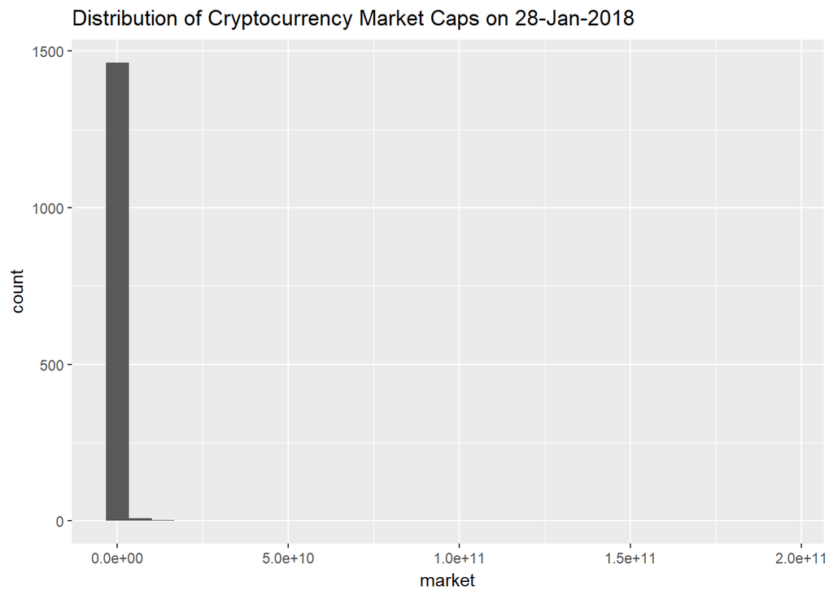

We can see that most coins have very small market caps compared to the big ones. The distribution is very right-skewed.

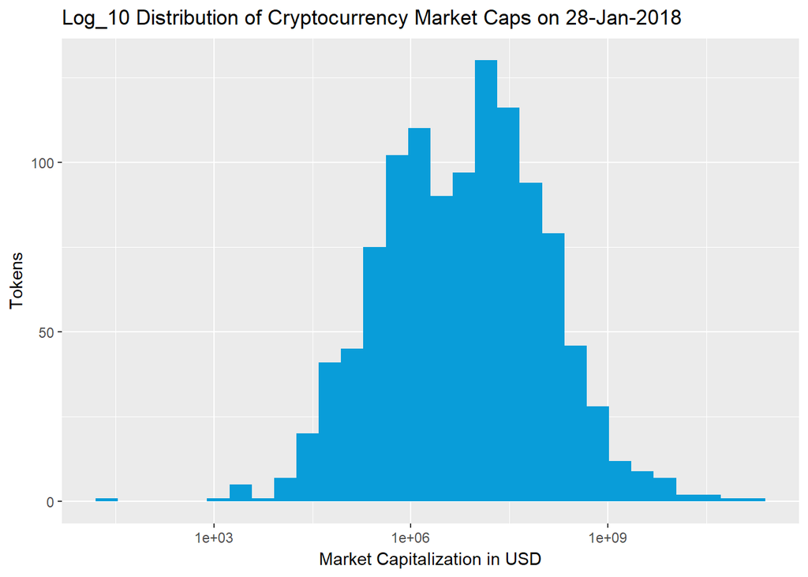

However, on a log scale it is very normally distributed.

Let’s look at a histogram of token price.

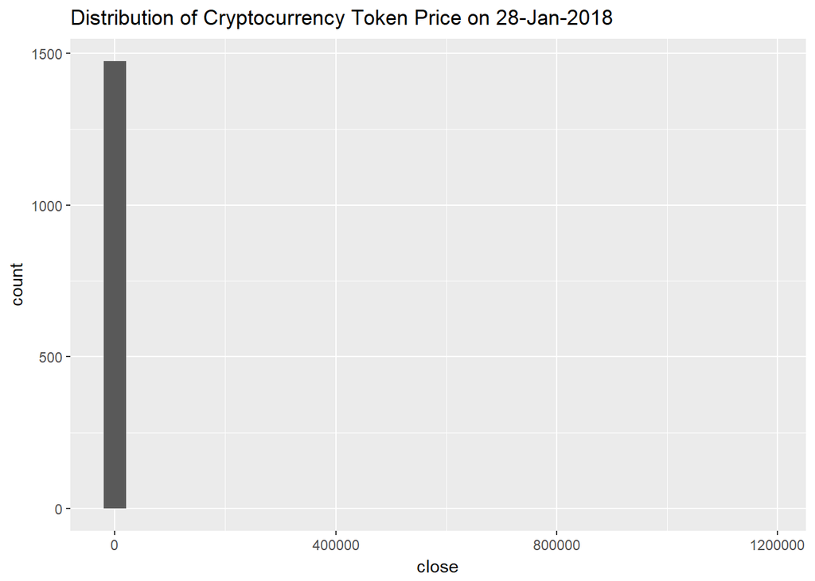

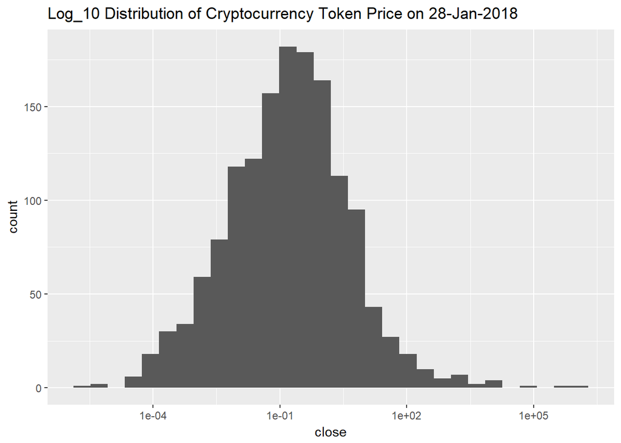

Price is also log normally distributed. Let’s look at trading volume.

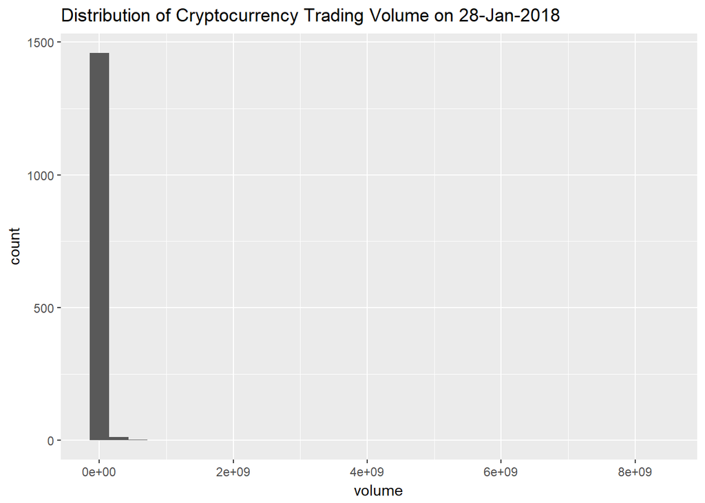

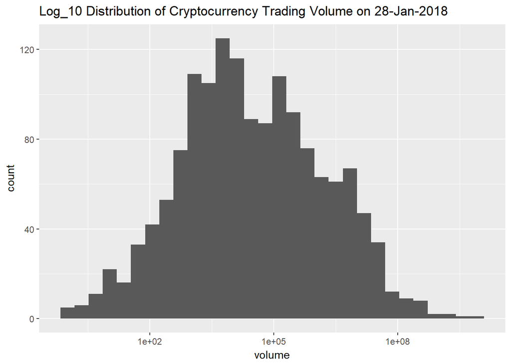

Trading Volume is also log normally distributed.

Since we know that most of the market is in the top coins. Let’s find out how much exactly.

```
## [1] 0.9686859
```

Although we have 1494 tokens. We can see that 96.9% of the market capitalization is invested in only 10% of the tokens.

```
## [1] 0.8307254
```

That 83.1% of the market is in only 1% of the tokens.

```
## [1] 0.7526056
```

And that 75.3% of the market is in the top 0.5% of tokens.

What are those top 0.5% of tokens with 3/4 of the money?

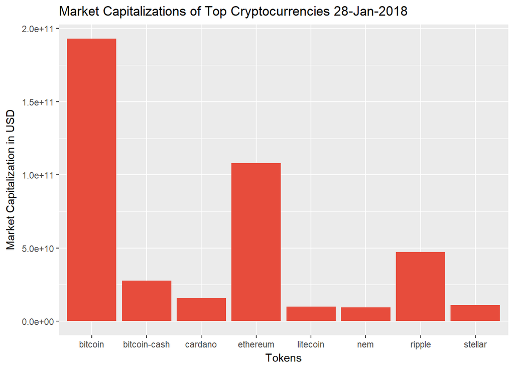

Here we see that even within the top 0.5% that Bitcoin, Ethereum and Ripple dominate. This is a very top heavy market.

Let’s look at some statistical summaries of the marketcap data for 28-Jan-2018.

```
##      Min.   1st Qu.    Median      Mean   3rd Qu.      Max.
## 0.000e+00 1.545e+04 1.735e+06 3.802e+08 2.466e+07 1.931e+11
```

```
##           0%          10%          50%          90%         100%
##            0            0      1734725    145499700 193133000000
```

Here we can see that 50% of the tokens have a market capitalization of $1.7 million or less and 90% have a market cap of $145 million or less.

# Univariate Analysis

### What is the structure of your dataset?

The dataset has 672,996 observations and 14 Variables describing 1,494 Crypto Tokens from 28-Apr-2013 to 28-Jan-2018.

This dataset describes the price, market and trading volume information of crypto tokens, and how they change over time.

In this section I explored a snapshot in time of the cryptocurrency market as of 28-Jan-2018.

I was able to see that the price, marketcap, and trading volume of the 1494 observed tokens was log-normally distributed. The vast majority of capital and trading is happening in the biggest tokens.

I also found that although we have 1494 tokens. The top 10% of the tokens represent 96.9% of the cryptocurrency marketcap. And the top 1% of the tokens represent 83.1%.

### What is/are the main feature(s) of interest in your dataset?

The main features of interest in this dataset are token price/market capitalization and how they change over time.

### What other features in the dataset do you think will help support your investigation into your feature(s) of interest?

The feature of interest that I will explore more from here is the time variable. I will explore how the cryptocurrency market capitalization changes over time. How the individual tokens change over time. And how correlated these changes are to eachother.

As well, it may be interesting to look at how trading volume is related to market capitulation.

### Did you create any new variables from existing variables in the dataset?

I created 4 new variables.

daily_total_market - is the total cryptocurrency market capitalization of that day

market_share - is the token market share of the total cryptocurrency market cap of that day

date_started_tracking - is the date coinmarketcap.com started tracking the token

year_started_tracking - is the year coinmarketcap.com started tracking the token

### Of the features you investigated, were there any unusual distributions? Did you perform any operations on the data to tidy, adjust, or change the form of the data? If so, why did you do this?

The cryptocurrency space as of 28-Jan-2018 is log-normally distributed for major token attributes such as trading volume, market capitalization and token price.

The top 10% of tokens account for 96.9% of the total market, and the top 1% account for 83.1% of total market.

Even among the top 1% of tokens Bitcoin, Ethereum, and Ripple are the dominant tokens. I will explore marketshare dominance more in the next section.

I deleted the variables name, closing ratio, and spread. Closing ratio was full of NA values and I didn’t see a need to use any of these 3 variables.

As per the creator of the scraping tool (documentation found here: https://github.com/JesseVent/crypto) the variable slug is the unique reference for each token.

Therefore, I used the variable slug as my reference for the token name, and changed the column name “slug” to column name “name” to reflect this.

I created a dataframe for only 2017 data (crypto_2017) because 2017 was the year where most of the action occurred in the cryptocurrency world and I wanted to explore it in more detail in the next section.

I created the single day dataframe (crypto_28-jan-2018) to be able to take a better look at a snapshot in time of the data before exploring the changes that occurred over time.

# Bivariate Plots Section

In this section we’ll explore how multiple variables interact.

First, let’s look at how the total cryptocurrency market, number of tokens and trading volume have grown over time.

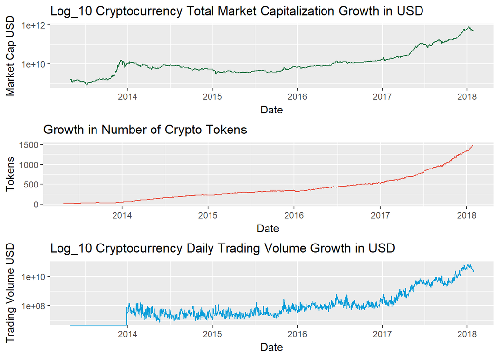

Wow. That’s growth. Both trading volume and total marketcap have increased exponentially since 2014. The number of tokens is also increasing rapidly although I wouldn’t say exponentially. Let’s look at only 2017 now.

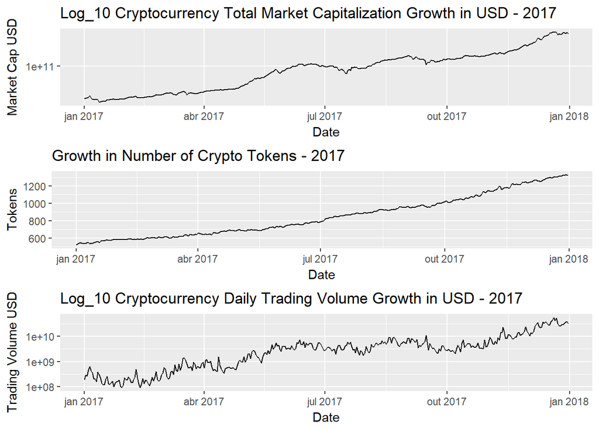

An enormous amount of growth in just 1 year. 2017 was a crazy year for the cryptocurrency market.

But was the growth evenly distributed? Let’s take a look at the 2017 price growth of the top coins.

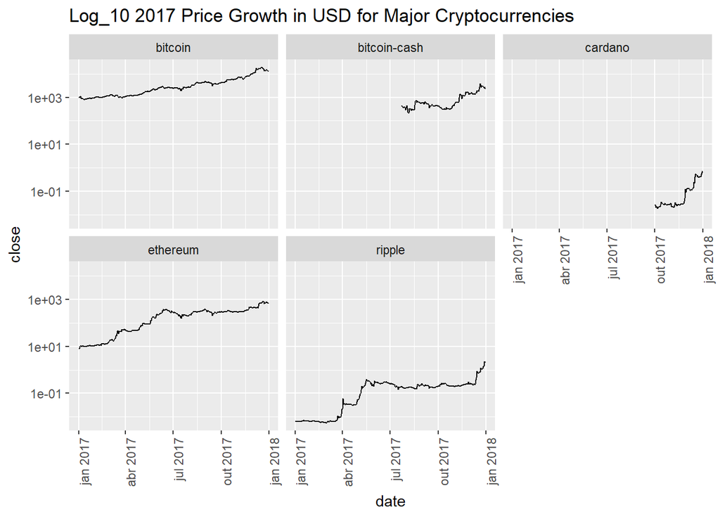

Price grew exponentially for these 5 major currencies. Let’s look at marketcap

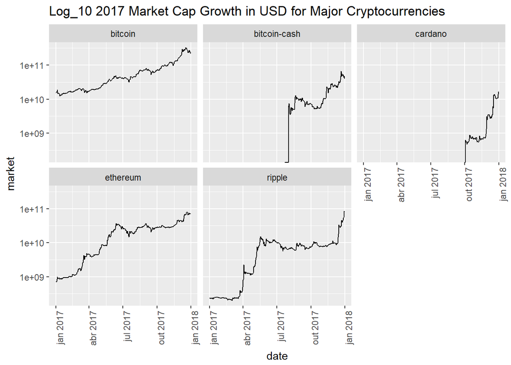

Market cap grew exponentially as well. Maybe the best thing to do is to look at the ratio of change in price during the year.

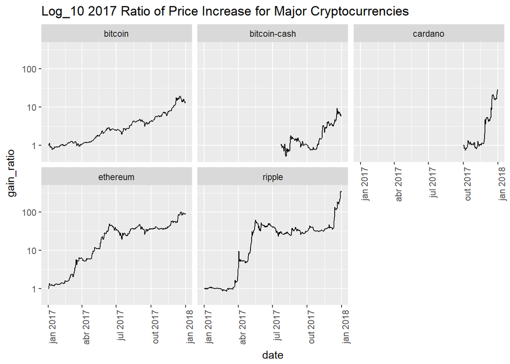

Looks like Ripple grew substantially in 2017. Ripple increased in price by more than 300x. To see more clearly the other major tokens let’s remove ripple from the next plot and plot on a linear scale.

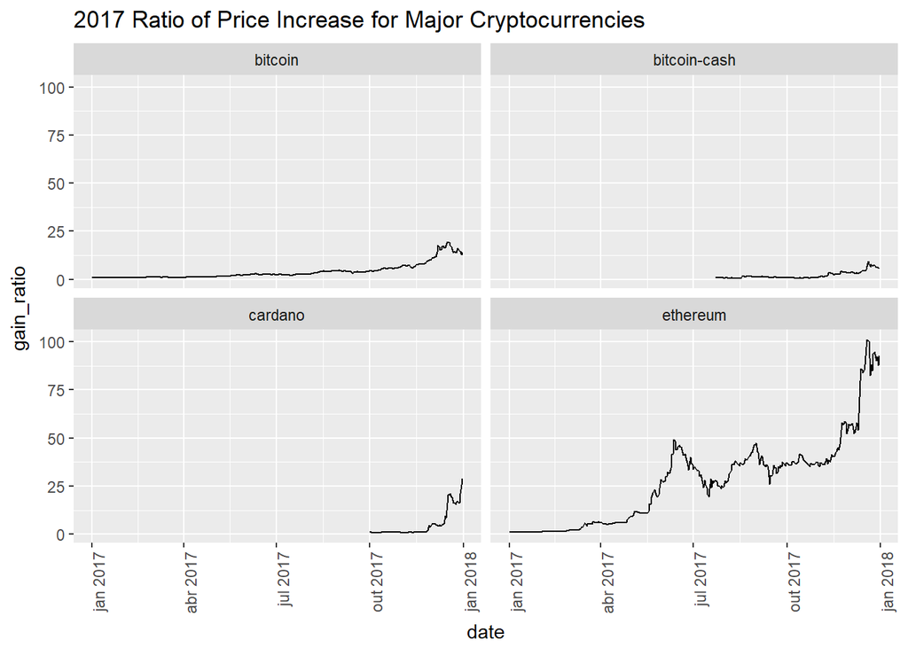

Here we can see that etheruem also grew a lot in 2017, up almost 100x.

Now, let’s see who were the biggest gainers in 2017. Because data on the smallest tokens can be unreliable I will look at only tokens that ended the year with at least $100 million in market cap.

```
## # A tibble: 50 x 3
## # Groups:   name [50]
##    name              gain_ratio     market
##    <fct>                  <dbl>      <dbl>
##  1 experience-points      40356  206952000
##  2 verge                  10118 2034410000
##  3 bitconnect              2877 2355660000
##  4 xtrabytes               2842  161560000
##  5 raiblocks               2497 1603630000
##  6 pivx                    1475  525926000
##  7 hempcoin                1326  104694000
##  8 shift                   1103  101449000
##  9 triggers                1087  171241000
## 10 einsteinium              700  157142000
## # ... with 40 more rows
```

Some tokens had insane growth in 2017. Experience-points went up 40,355x and verge went up 10,118x.

Ethereum, which is one of the largest players and highly respected in the cryptocurrency space went up 92.6x. As amazing as this is it was still only the 38th biggest gainer of the year with marketcap over $100,000,000.

Is there any correlation between the top gaining coins and their end of year market cap?

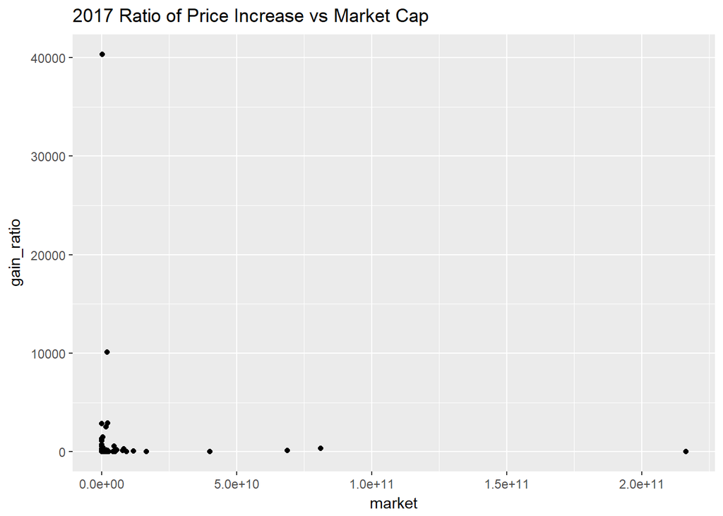

It doesn’t look like it. Let’s remove the largest 5% from both variables and try again.

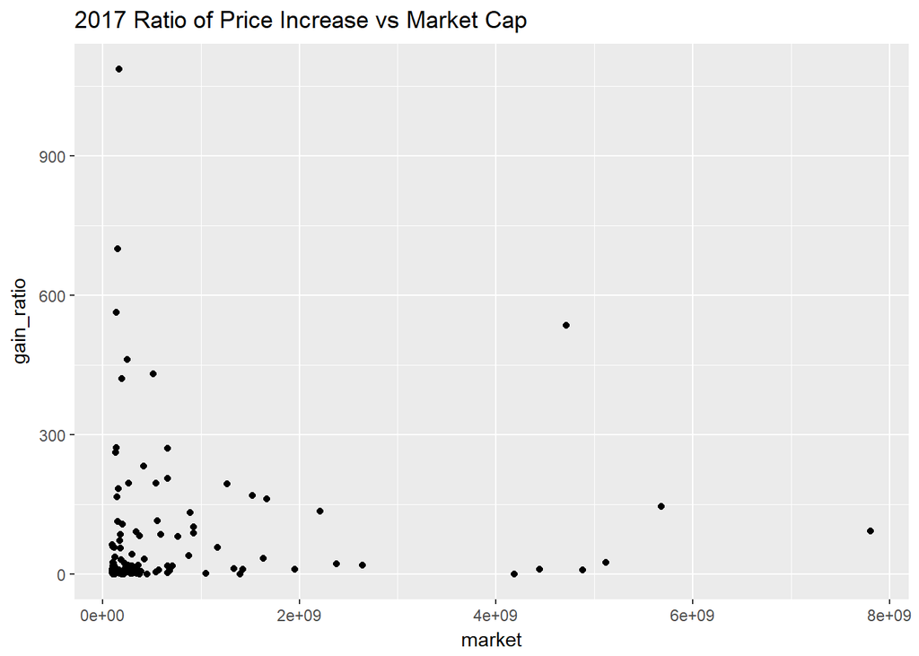

I still don’t see a relationship here.

What if we look at the relationship logarithmically.

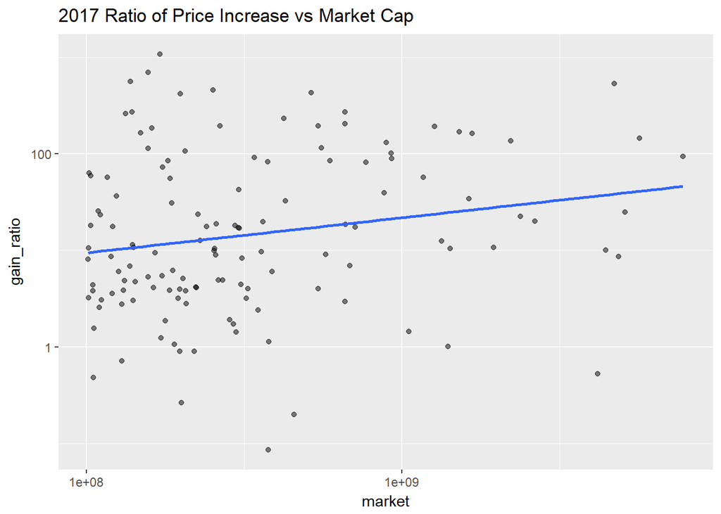

There may be a weak relationship here between 2017 ratio of price increase and market cap.

However, this is as far as I will explore this relationship.

Now, let’s look the distribution of gains of the various tokens in 2017

### Distribution of Gains in 2017

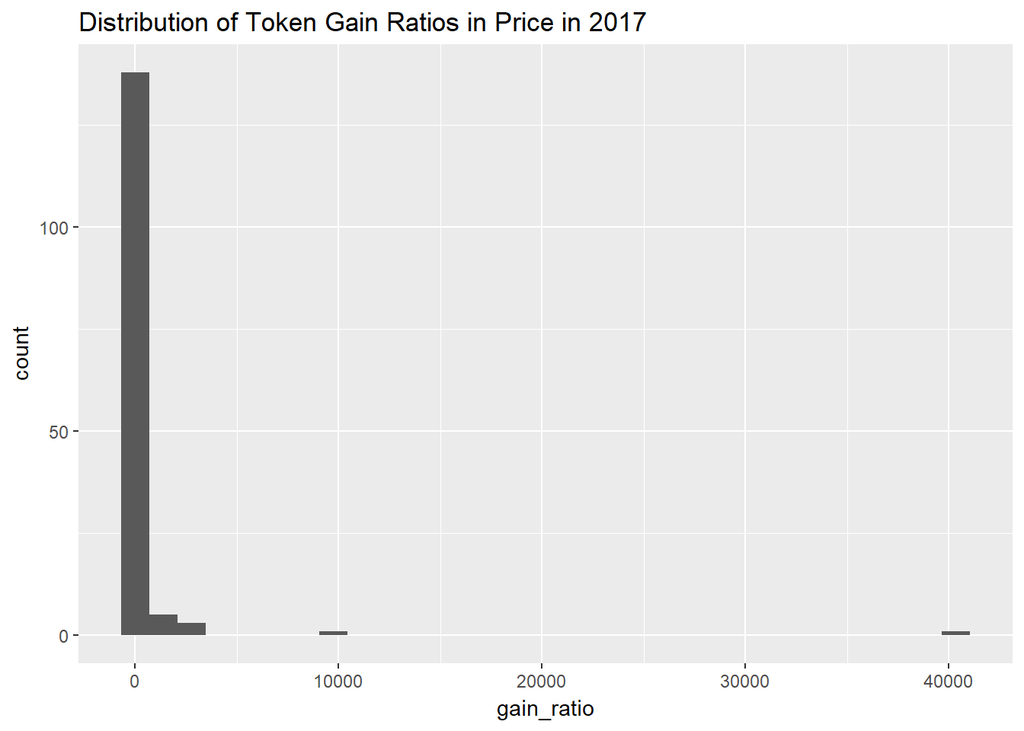

Gains are heavily right skewed.

What about a statistical summary?

```
##             name       gain_ratio           market
##  0x           :  1   Min.   :    0.09   Min.   :1.013e+08
##  achain       :  1   1st Qu.:    4.12   1st Qu.:1.571e+08
##  adx-net      :  1   Median :   15.58   Median :2.600e+08
##  aelf         :  1   Mean   :  492.39   Mean   :3.713e+09
##  aeternity    :  1   3rd Qu.:   92.88   3rd Qu.:6.911e+08
##  agoras-tokens:  1   Max.   :40355.56   Max.   :2.163e+11
##  (Other)      :142
```

Here we can clearly see that there were some tokens with huge gains in 2017 in the cryptocurrency world. However it was extremely right skewed. The median gain was 15.58 and the mean gain 492.39.

Let’s look at it on a log scale.

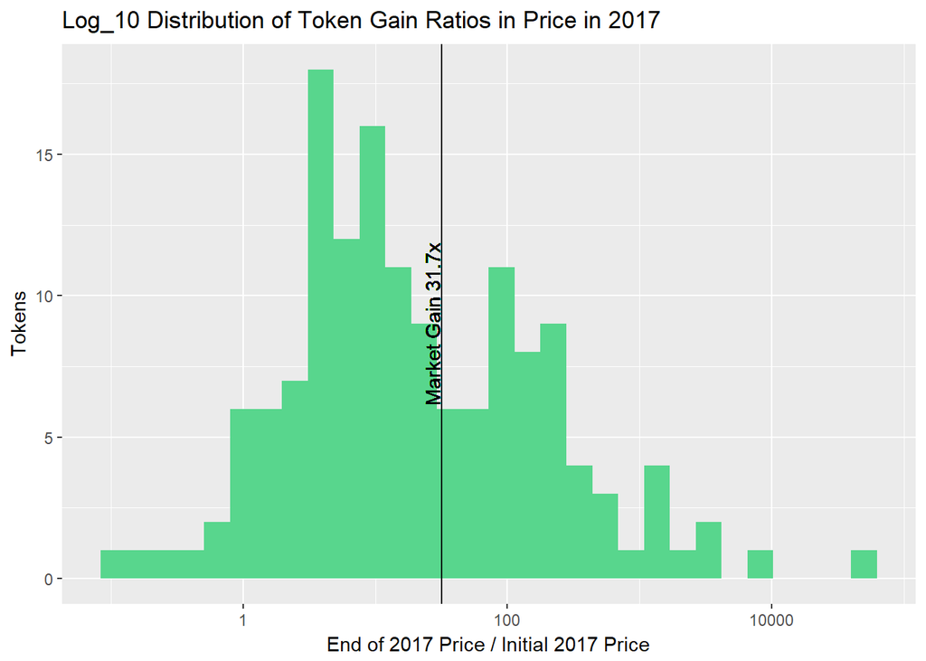

Even the gains that tokens make is log normally distributed. A few coins gained a ton while the vast majority gained a little.

```
##           0%          10%          50%          90%         100%
## 8.535565e-02 1.668872e+00 1.558225e+01 3.791433e+02 4.035556e+04
```

Here we can see that 50% of the coins gained less than 15.6x and 90% gained less than 379x.

How much did the total cryptocurrency market gain as a whole in 2017?

```
## [1] 31.7192
```

The total market increased 31.7x in 2017.

Is there a correlation between trading volume and marketcap?

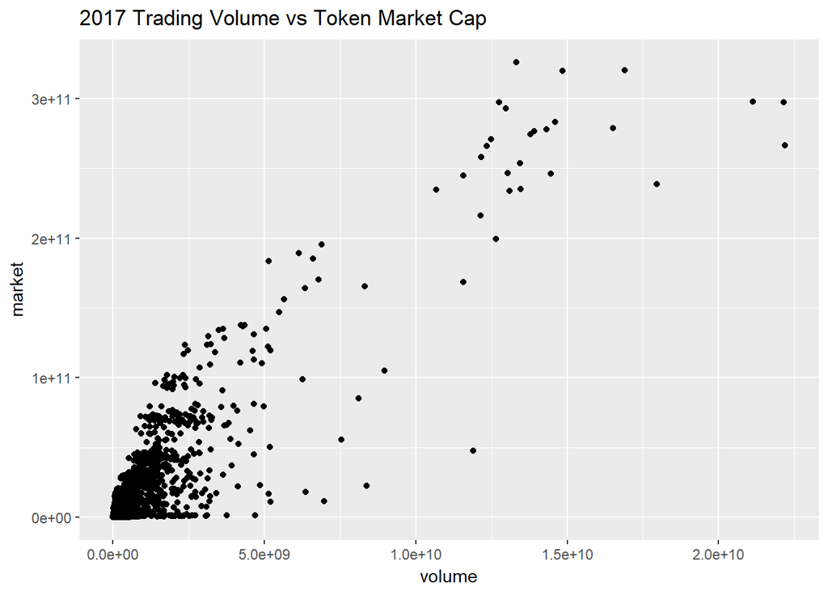

It looks like there is a relationship.

Let’s do a linear regression to see how strong it is.

```
##
## Calls:
## m1: lm(formula = I(volume) ~ I(market), data = crypto_2017)
##
## =================================================
##   (Intercept)                      32991.772
##                                  (132797.715)
##   I(market)                            0.045***
##                                       (0.000)
## -------------------------------------------------
##   R-squared                            0.813
##   adj. R-squared                       0.813
##   sigma                         73869580.425
##   F                              1343374.589
##   p                                    0.000
##   Log-likelihood                -6056469.710
##   Deviance        1691592536187356053544.000
##   AIC                           12112945.420
##   BIC                           12112977.353
##   N                               310004
## =================================================
```

R-squared of 0.813 shows there is a correlation. The bigger the market the higher the trading volume.

Now, let’s come back to 28-Jan-2018 for a moment. This time let’s examine our data by categorizing our tokens by the year they began being tracked on coinmarketcap.com.

### Is the Year a Token was Introduced Related to it’s Market Cap?

Let’s look at the distribution of the token marketcaps on 28-Jan-2018 based on the year that the token was introduced.

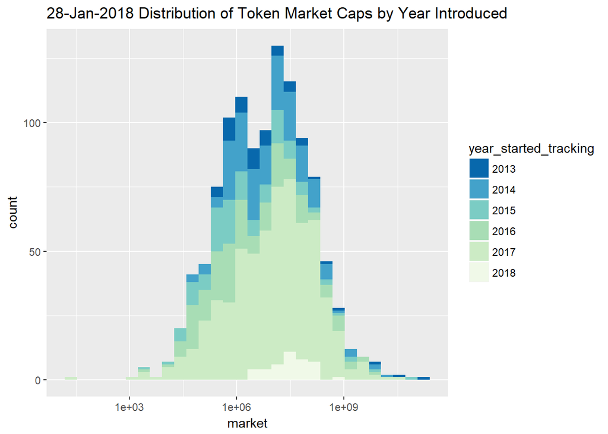

Here we see the distributions of the market caps in boxplot form..

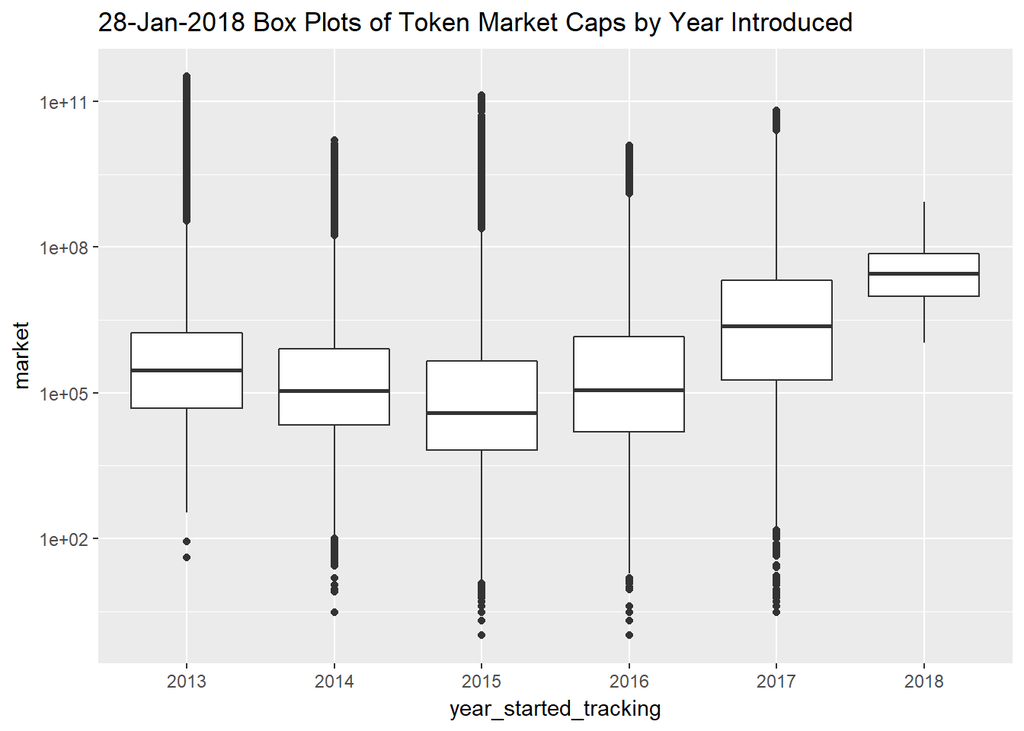

It looks like the newer tokens make up the majority of mid-priced tokens and the older tokens still have the largest market caps.

Let’s look more at the marketcaps of tokens based on year introduced

```
## # A tibble: 6 x 6
##   year_started_tracking     max_mrkt min_mrkt  mean_mkrt median_mrkt     n
##   <fct>                        <dbl>    <dbl>      <dbl>       <dbl> <int>
## 1 2013                  193133000000        0 4670412245     2863210    54
## 2 2014                   11005200000        0  174379282     4069930   187
## 3 2015                  108122000000        0  887282128      542954   139
## 4 2016                    9124100000        0  117361960      437536   228
## 5 2017                   27713300000        0  172500508     4639895   722
## 6 2018                     600608000        0   17131289           0   148
```

Here we can see that we have less older tokens but they make up the majority of the market capitalization.

Let’s look at the top 10% of the market

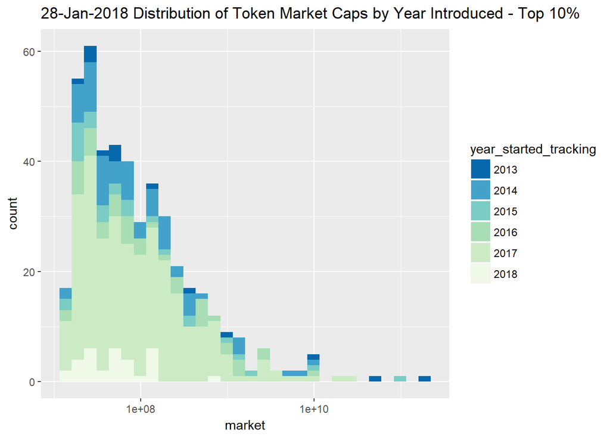

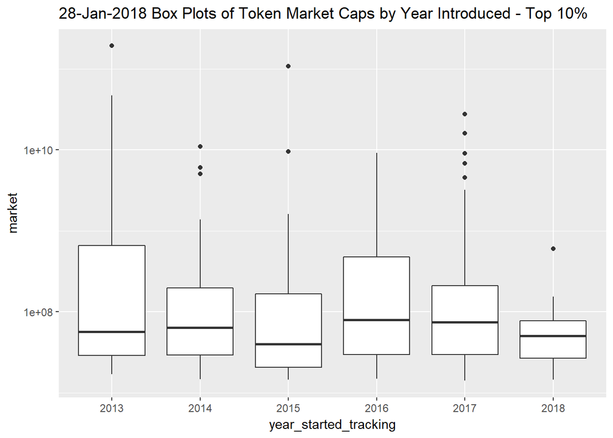

And the top 1%

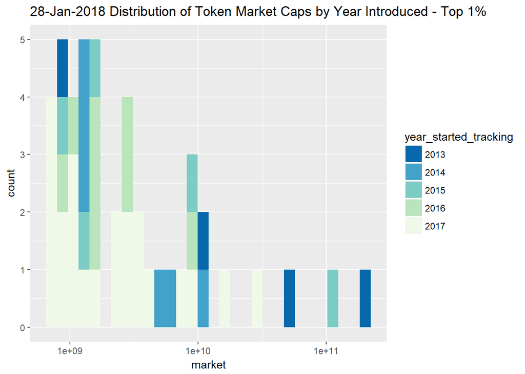

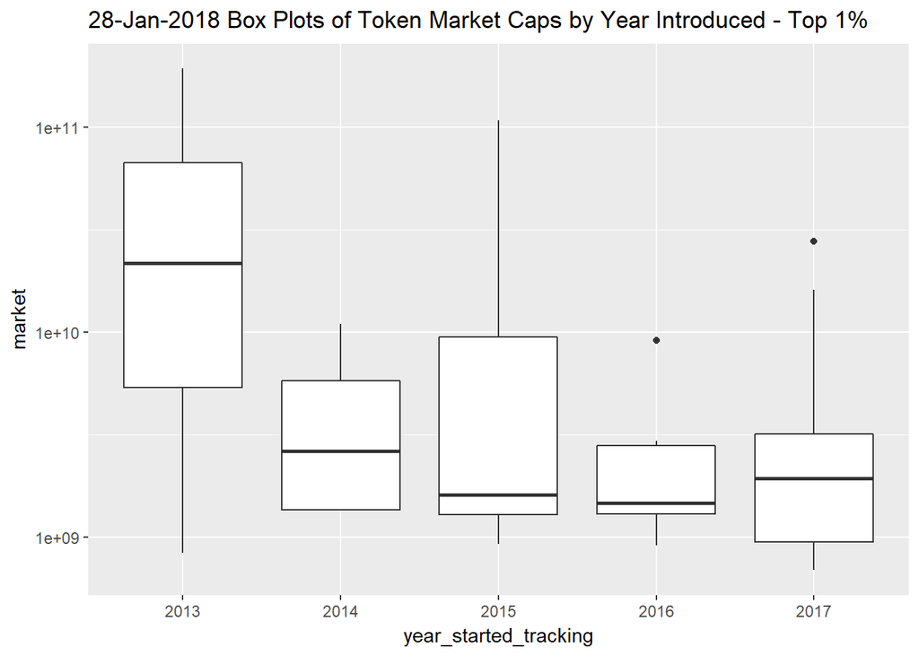

Here it becomes clear that the very largest marketcaps belong to older tokens but some of the tokens introduced in 2017 are beginning to invade the top 1%.

### Correlation Among Tokens and the Overall Market

Now I would like to look at correlations among tokens.

I want to see how correlated changes in marketcap over time are between the top tokens and how related each token is to the market as a whole.

Let’s build a correlation matrix for some of the top cryptocurrencies.

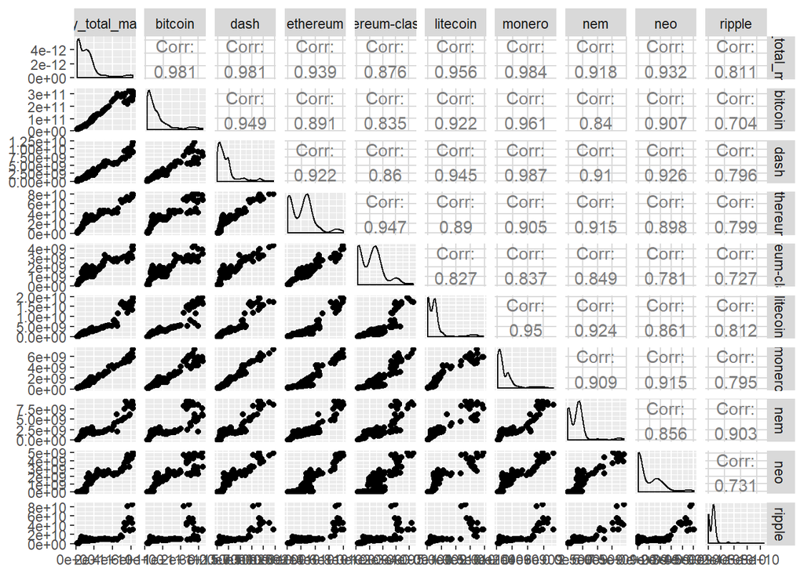

We see that monero, bitcoin and dash are very highly correlated to the changes in the overall market. Whereas ripple is the least correlated to overall market with R = 0.811.

Now I will look at the correlation of all of the tokens change in marketcap vs the change in marketcap of the overall cryptocurrency market for 2017.

```
##                 token         R
## 1: daily_total_market 1.0000000
## 2:             monero 0.9843218
## 3:               dash 0.9813595
## 4:            bitcoin 0.9810990
## 5:            bitsend 0.9708982
## 6:             tether 0.9654855
```

This list shows the tokens most correlated to the overall market. Monero, Dash and Bitcoin are very highly correlated to the overall market.

Now let’s plot the distribution of correlation coefficients

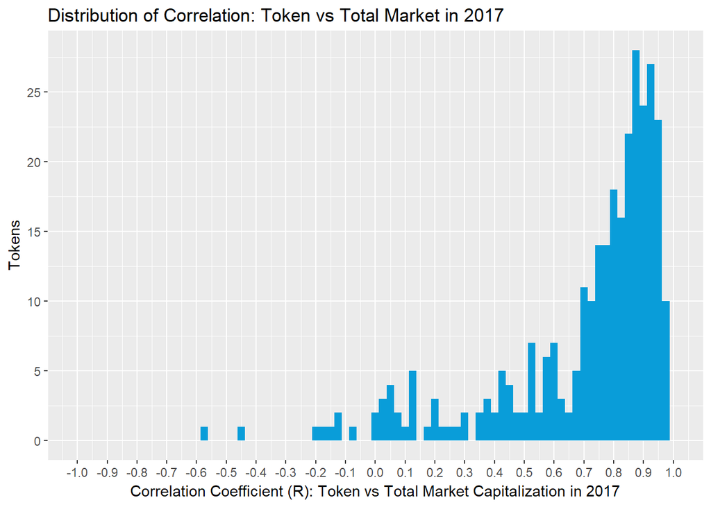

Here we see the distribution of correlations of tokens to the overall market for 2017. Most of the tokens are highly correlated. However there is a considerable amount of tokens that are not correlated.

# Bivariate Analysis

### Talk about some of the relationships you observed in this part of the investigation. How did the feature(s) of interest vary with other features in the dataset?

The market capitalization of cryptocurrencies has increased exponentially since 2013 and especially in 2017.

In 2017, some tokens increased in value as much as 40,000x. However, the increase of value in tokens wasn’t uniform. It was log normally distributed with the top performing tokens drastically outgaining the rest.

50% of the tokens gained less than 15.6x and 90% gained less than 379x.

The market as a whole gained 31.7x in 2017.

### Did you observe any interesting relationships between the other features (not the main feature(s) of interest)?

I observed that 2017 rise in price appears to have no correlation to end of year market cap of tokens.

I also saw that trading volume had a linear relationship to market cap size with r^2 = 0.813

### What was the strongest relationship you found?

The strongest relationship is in the exponential rise of token market capitalization over time. The correlation among tokens is very strong for the tokens with the largest market cap but it is highly dispersed among smaller tokens.

# Multivariate Plots Section

In this section I will investigate some final multi-variate relationships.

Here I plot the performance of some of the tokens with the largest market caps against eachother for 2017.

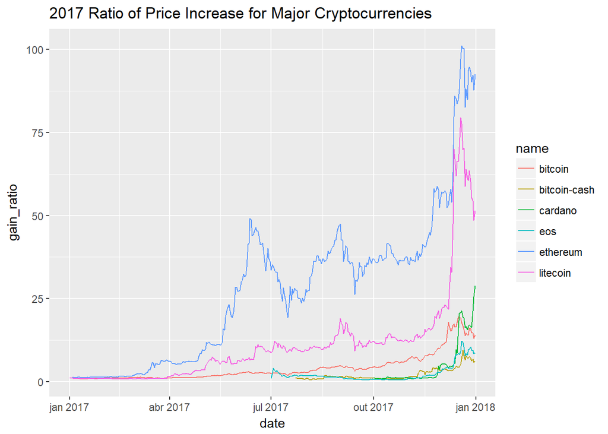

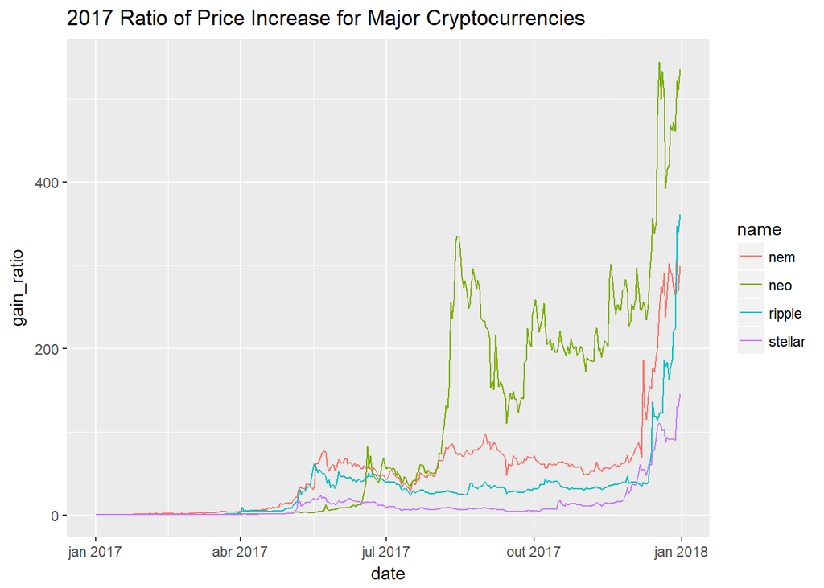

All of the major coins increased in value in 2017. The biggest winners were NEO which went up over 500x and now is one of the biggest tokens in the market. As well as, NEM and Ripple which both went up 300x or more.

Below, we look at whether investing in older or newer currencies would have resulted in more gains for 2017.

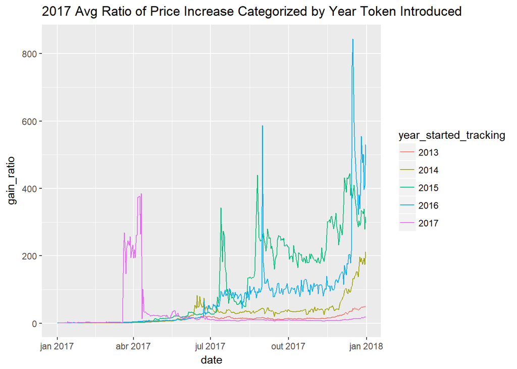

It’s not clear.

But, it looks like if you had spread your investments in tokens that started from 2016 and 2015 you would have made the best return.